# Machine Learning Course Project

Temi A. Sorungbe

September 20, 2016

## Summary

This project analyzes the wearable computing dataset- a large amount of data quantifying how well people execute their personal fitness activity . Specifically, data from accelerometers on the belt, forearm, arm, and dumbell of 6 participants are recorded while they perform barbell lifts correctly and incorrectly in 5 different ways.

The cross validated random forest model best predicts how well each participants executes the barbell lifts and was selected as the final predictive model for the wearable computing dataset.

This model was selected after preprocessing the train dataset to select key features and comparing prediction accuracy of linear discriminant analysis (lda), quadratic discriminant analysis (qda) and classification and regression tree (CART) methods- rpart and random forest.

# Pre-processing

The following steps were carried out on the train, validation and test dataset:

1. Selecting features from the training dataset to be used for predictions by:
1. removing variables with high missingness (> 95%)
2. removing near zero variance variables
3. removing highly correlated variables (ie. correlations > 0.75)
2. Centering and scaling all variables except “classe”

# Explore the data

The following plots display the relationships between selected features and the classe variables in the train dataset.

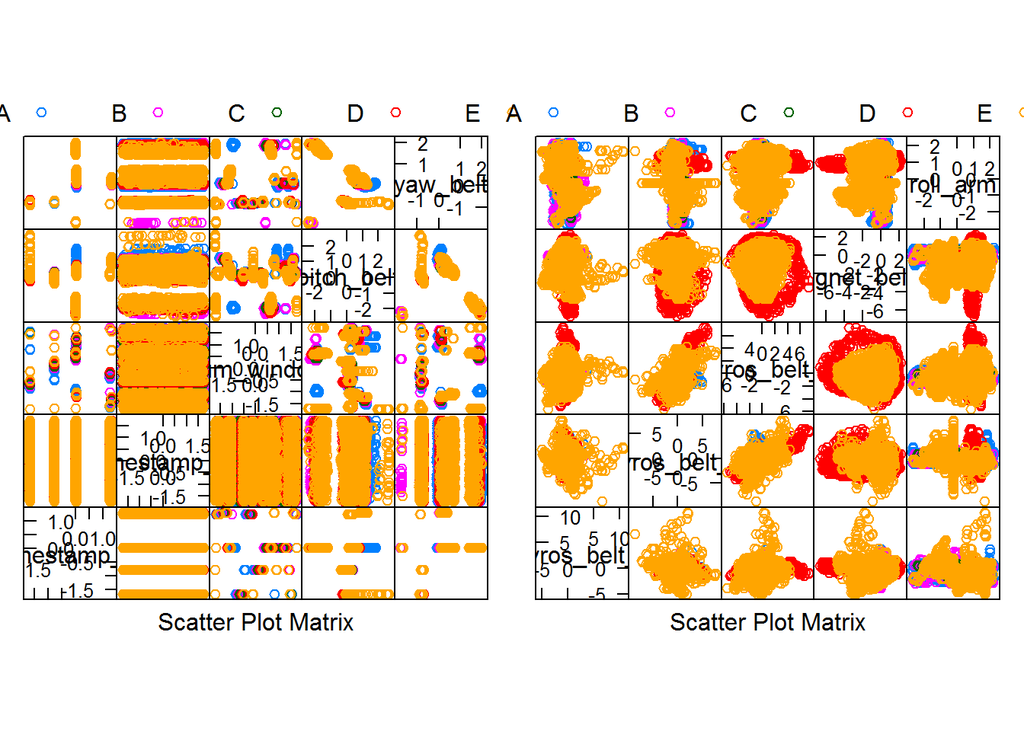

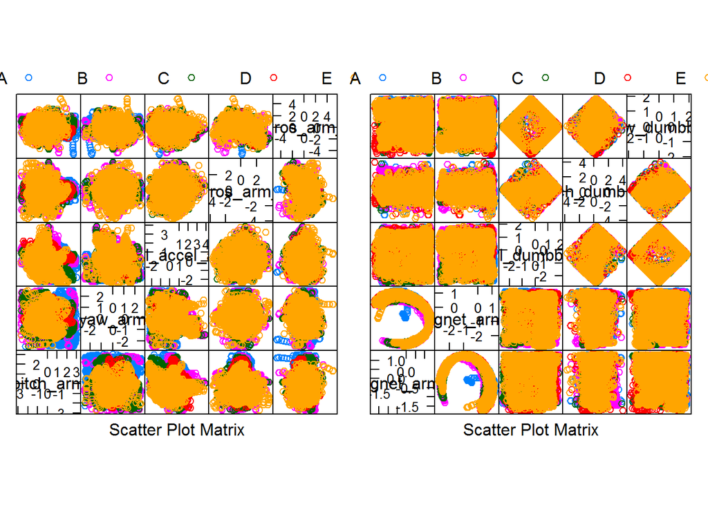

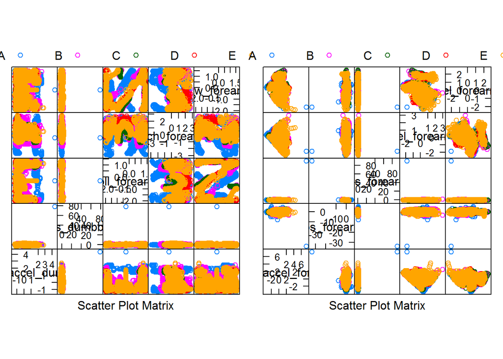

## Modelling, model assessment and model selection

The “classe” variable will be predicted using the following classification methods:

1. linear discriminat analysis (assuming common variance across classes)
2. quadratic discriminat analysis (assuming class specific variance)
3. classification and regression trees (rpart and random forests)

# Results

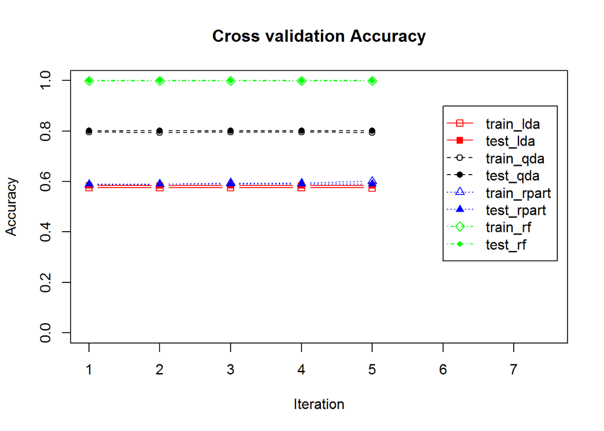

# Final model

The random forest model gives the most accurate prediction of the classe variable in the validation dataset with an average prediction accuracy (across 5 iterations) of **1** versus **0.5838164** from the linear discriminant analysis model, **0.8007246** from the quadratic discriminant analysis model, and **0.5903382** from the classification and regression trees model (rpart).

# Predictions

Random forest model predictions on the test dataset are: B, A, B, A, A, E, D, B, A, A, B, C, B, A, E, E, A, B, B, B